# DSCapstone-SwiftKey data Analysis - Milestone Report

Ariful I. Mondal

13 November 2017

# 1 Synopsis - Data Science Capstone Project

This milestone report is part of the data science capstone project from [“Data Science Specialization”](https://www.coursera.org/specializations/jhu-data-science) Learning path on [Coursera](https://www.coursera.org) by [Johns Hopkins University](https://www.jhu.edu/). The capstone project class allows students to create a usable/public data product that can be used to show your skills to potential employers. Projects is drawn from real-world problems and will be conducted with industry, government, and academic partners. This project is supported by [SwiftKey](https://swiftkey.com/en), corporate partner in this capstone, builds a smart keyboard that makes it easier for people to type on their mobile devices.

# 2 Introduction

Around the world, people are spending an increasing amount of time on their mobile devices for email, social networking, banking and a whole range of other activities. But typing on mobile devices can be a serious pain. SwiftKey, our corporate partner in this capstone, builds a smart keyboard that makes it easier for people to type on their mobile devices. One cornerstone of their smart keyboard is predictive text models. When someone types:

“I went to the”"

the keyboard presents three options for what the next word might be. For example, the three words might be gym, store, restaurant. In this capstone you will work on understanding and building predictive text models like those used by SwiftKey.

In this project we will start with the basics, analyzing a large corpus of text documents to discover the structure in the data and how words are put together. It will cover cleaning and analyzing text data, then building and sampling from a predictive text model. Finally, you will use the knowledge you gained in data products to build a predictive text product you can show off to your family, friends, and potential employers.

# 3 About the Data

This is the training data to get you started that will be the basis for most of the capstone. In this project I will use the data from the Coursera site as instructed in the coursera course from below link.

[Capstone Dataset](https://d396qusza40orc.cloudfront.net/dsscapstone/dataset/Coursera-SwiftKey.zip)

We have text documents in 4 different languages such as English, US (`en_US`, ~550MB), German (`de_DE`, ~240MB), Russian (ru_RU, ~325MB) and Finish (`fi_FI`, ~220MB) in the forms of `blogs`, `news and`twitter`. I am planning to use English, US data for this analysis where we have

- en_US.blogs.txt (~200MB)
- en_US.news.txt (~200MB)
- en_US.twitter.txt (~160MB)

I have downloaded the data manually but it can be downloaded diagrammatically using below scripts

```r
setwd("D:\\dscapstone")  # Project Workspace

wbsource<-"https://d396qusza40orc.cloudfront.net/dsscapstone/dataset/Coursera-SwiftKey.zip" # Data Scource

projFileName<-"Coursera-SwiftKey.zip" # Destination.

download.file(wbsource, projWorkspace) # Download and save

unzip(projFileName)  # Uncompress file
```

# 4 Scope of the project

In this capstone project we would be performing following tasks in order to achieve the overall objective of the project:

- Understanding the problem
- Data acquisition and cleaning
- Exploratory analysis
- Statistical modeling
- Predictive modeling
- Creative exploration
- Creating a data product
- Creating a short slide deck pitching your product

# 5 Preditive Model Development Goals

The goal of this exercise is to build and evaluate your first predictive model. You will use the n-gram and backoff models you built in previous tasks to build and evaluate your predictive model. The goal is to make the model efficient and accurate.

## 5.1 Tasks to accomplish

- Build a predictive model based on the previous data modeling steps - you may combine the models in any way you think is appropriate
- Evaluate the model for efficiency and accuracy - use timing software to evaluate the computational complexity of your model
- Evaluate the model accuracy using different metrics like perplexity, accuracy at the first word, second word, and third word
- Explore new models and data to improve your predictive model
- Evaluate your new predictions on both accuracy and efficiency

### 5.1.1 Questions to consider

- How does the model perform for different choices of the parameters and size of the model?
- How much does the model slow down for the performance you gain?
- Does perplexity correlate with the other measures of accuracy?
- Can you reduce the size of the model (number of parameters) without reducing performance?

# 6 Required **R** packages

I am planning to use following R packages. We would need to install these packages if they are not installed already using `install.packages()` and load them using `library()`.

- [**tm:**](https://cran.r-project.org/web/packages/tm/tm.pdf) for text mining and natural language processing(NLP)
- [**wordcloud:**](https://cran.r-project.org/web/packages/wordcloud/wordcloud.pdf) to create word clouds
- [**stringi:**](https://cran.r-project.org/web/packages/stringi/stringi.pdf) to leverage character string processing facilities
- [**clue:**](https://cran.r-project.org/web/packages/clue/clue.pdf) for Cluster Ensembles
- [**SnowballC:**](https://cran.r-project.org/web/packages/SnowballC/SnowballC.pdf) for stemming text
- [**RColorBrewer:**](https://cran.r-project.org/web/packages/RColorBrewer/RColorBrewer.pdf) color palettes for nice colours of the graphs
- [**RWeka:**](https://cran.r-project.org/web/packages/RWeka/RWeka.pdf) text mining and N-Gram analysis
- [**ggplot2:**](https://cran.r-project.org/package=ggplot2/ggplot2.pdf) to Create Elegant Data Visualizations Using the Grammar of Graphics
- [**qdap:**](https://cran.r-project.org/web/packages/qdap/index.html) Bridging the Gap Between Qualitative Data and Quantitative Analysis

```r
## Load Packages
library("tm")
library("stringi")
library("wordcloud")
library("clue")
library("ggplot2")
library("RColorBrewer")
library("SnowballC")
library("RWeka")
library("qdap")
```

# 7 Check for data availability

Before going ahead, it is important to to download the data keep in the right path. So I wish to check whether they files exist, if not then download from the web-source.

```r
setwd("D:\\dscapstone")

# Check if the file has been extracted
if (!file.exists("./final")) {

  if(!file.exists("Swiftkey.zip")){
    url = "https://d396qusza40orc.cloudfront.net/dsscapstone/dataset/Coursera-SwiftKey.zip"
    download.file(url, "Swiftkey.zip", method = "curl")
    dateDownload <- date()
    }
  SwiftKey.zip<- "Coursera-SwiftKey.zip"
  outDir<-"."
  unzip(SwiftKey.zip,exdir=outDir)
}
```

# 8 Analysis of English, US data

For this project I am using documents with English-US (`en_US.blogs.txt`, `en_US.news.txt` and `en_US.twitter.txt`) , though I have documents with German, Russian and Finish.

## 8.1 Reading data

I have used `readLines()` function to read the text files, but for the large size of data we can also use a connection string.

```r
# Read files in the R using
us_blogs<-readLines("final\\en_US\\en_US.blogs.txt",  encoding = "UTF-8", skipNul = TRUE)
us_news<-readLines("final\\en_US\\en_US.news.txt",  encoding = "UTF-8", skipNul = TRUE)
us_twitter<-readLines("final\\en_US\\en_US.twitter.txt",  encoding = "UTF-8", skipNul = TRUE)
```

## 8.2 Summary and Structure of the data

### 8.2.1 Blogs summary

```r
# Summary US blogs
summary(us_blogs)
```

```
##    Length     Class      Mode
##    899288 character character
```

```r
# Structure of the data
str(us_blogs)
```

```
##  chr [1:899288] "In the years thereafter, most of the Oil fields and platforms were named after pagan gods." ...
```

#### 8.2.1.1 View few lines from the file `us_blog`:

```r
us_blogs[3:5]
```

```
## [1] "Chad has been awesome with the kids and holding down the fort while I work later than usual! The kids have been busy together playing Skylander on the XBox together, after Kyan cashed in his $$$ from his piggy bank. He wanted that game so bad and used his gift card from his birthday he has b…
## [2] "so anyways, i am going to share some home decor inspiration that i have been storing in my folder on the puter. i have all these amazing images stored away ready to come to life when we get our home."
## [3] "With graduation season right around the corner, Nancy has whipped up a fun set to help you out with not only your graduation cards and gifts, but any occasion that brings on a change in one's life. I stamped the images in Memento Tuxedo Black and cut them out with circle Nestabilities. I emb…
```

### 8.2.2 News summary

```r
# Summary US News
summary(us_news)
```

```
##    Length     Class      Mode
##     77259 character character
```

```r
str(us_news)
```

```
##  chr [1:77259] "He wasn't home alone, apparently." ...
```

#### 8.2.2.1 View few lines from the file `us_news`:

```r
us_news[3:5]
```

```
## [1] "WSU's plans quickly became a hot topic on local online sites. Though most people applauded plans for the new biomedical center, many deplored the potential loss of the building."
## [2] "The Alaimo Group of Mount Holly was up for a contract last fall to evaluate and suggest improvements to Trenton Water Works. But campaign finance records released this week show the two employees donated a total of $4,500 to the political action committee (PAC) Partners for Progress in early…
## [3] "And when it's often difficult to predict a law's impact, legislators should think twice before carrying any bill. Is it absolutely necessary? Is it an issue serious enough to merit their attention? Will it definitely not make the situation worse?"
```

### 8.2.3 Twitter Summary

```r
# Summary US Twitter
summary(us_twitter)
```

```
##    Length     Class      Mode
##   2360148 character character
```

```r
str(us_twitter)
```

```
##  chr [1:2360148] "How are you? Btw thanks for the RT. You gonna be in DC anytime soon? Love to see you. Been way, way too long." ...
```

#### 8.2.3.1 View few lines from the file `us_twitter`:

```r
us_twitter[3:5]
```

```
## [1] "they've decided its more fun if I don't."
## [2] "So Tired D; Played Lazer Tag & Ran A LOT D; Ughh Going To Sleep Like In 5 Minutes ;)"
## [3] "Words from a complete stranger! Made my birthday even better :)"
```

### 8.2.4 Longest lines in the files

```r
longest_lines<- (c(max(nchar(us_blogs)), max(nchar(us_news)), max(nchar(us_twitter))))
type <- c("US-Blogs", "US-News", "US-Twitter")
longest_lines <- as.data.frame(cbind(type,longest_lines))
colnames(longest_lines) <- c("file.name", "line.length")
longest_lines$line.length <- as.numeric(longest_lines$line.length)
print(longest_lines)
```

[output not shown]

### 8.2.5 Shortest lines in the files

```r
shortest_lines<-c(min(nchar(us_blogs)), min(nchar(us_news)), min(nchar(us_twitter)))
type <- c("US-Blogs", "US-News", "US-Twitter")
shortest_lines<-as.data.frame(cbind(type, shortest_lines))
colnames(shortest_lines) <- c("file.name", "line.length")
print(shortest_lines)
```

```
##    file.name line.length
## 1   US-Blogs           1
## 2    US-News           2
## 3 US-Twitter           2
```

## 8.3 Sampling Data

As we have large size of datasets to work with, we will use a representative sample for this project to improve performance of Shiny app and predictive models. I have randomly selected representative samples of the data for analysis and modeling using `sample()` function. This will help to reduce usage of memory and increase performance of the Shiny application.

```r
# Set random seed so that samples do not change
set.seed(12345)

# Sample from US-Blogs
# Help ?sample
us_blogs_sample <- sample(us_blogs, length(us_blogs)*0.01)

# Sample from US-News
us_news_sample <- sample(us_news, length(us_news)*0.10)

# Sample from US Twitter
us_twitter_sample <- sample(us_twitter, length(us_twitter)*0.01)

# Combine all the sample
us_data_sample <- c(us_blogs_sample,us_news_sample,us_twitter_sample)

# remove data to make some space
rm(list=c("type", "us_blogs", "us_news", "us_twitter", "us_blogs_sample", "us_news_sample", "us_twitter_sample"))
```

```r
# Quick check on data structure
us_data_sample[1:3]
```

```
## [1] "And now Im home. Older, wiser, a little slimmer and hopefully secure in the knowledge of what Im good at, and what I want to do with my time."
## [2] "I turned the Today show on to catch up on the morning's news and immediately I knew something terrible had happened in New York City."
## [3] "Ill take this opportunity to diverge from the usual Take Three path, and, instead of focusing on one last role, offer up an Arkin Remix - a concisely-potted overview. Arkin has long been seen as one of the exemplary supporting actors. So many of his roles before his resurgence in popularity …
```

```r
summary(us_data_sample)
```

```
##    Length     Class      Mode
##     40318 character character
```

## 8.4 Preprocessing of Text Data

Before performing analysis on Text data, we will preprocess the data parse, clean and transform as necessary for better results and predictions.

#### 8.4.0.1 Remove special characters

- Remove non-English characters, letters etc. using `iconv()` and option `latin1`
- Remove special characters with spaces using `gsub()` and regular expression `[^0-9a-z]`
- Remove duplicate characters using `gsub()` and regular expression
- Remove special numbers with spaces using `gsub()` and regular expression
- Remove multiple spaces to one using `gsub()` and regular expression

To know more on `incon()` click [here](https://www.rdocumentation.org/packages/base/versions/3.4.1/topics/iconv), for `gsub()` click [here](https://www.r-bloggers.com/regular-expression-and-associated-functions-in-r/) and click [here](https://en.wikipedia.org/wiki/Regular_expression) to know more on `regular expression`, also view [`regex`](https://stat.ethz.ch/R-manual/R-devel/library/base/html/regex.html).

```r
# Remove non-English characters, letters etc.
# Help ?inconv
us_data_sample<-iconv(us_data_sample, "latin1", "ASCII", sub="")

# Remove special characters with spaces
# Help ?gsub
us_data_sample_1 <- gsub("[^0-9a-z]", " ", us_data_sample, ignore.case = TRUE)
rm(us_data_sample)

# Remove duplicate characters
us_data_sample_1 <- gsub('([[:alpha:]])\\1+', '\\1\\1', us_data_sample_1)

# Remove special numbers with spaces
us_data_sample_1 <- gsub("[^a-z]", " ", us_data_sample_1, ignore.case = TRUE)

# Remove multiple spaces to one
us_data_sample_1 <- gsub("\\s+", " ", us_data_sample_1)
us_data_sample_1 <- gsub("^\\s", "", us_data_sample_1)
us_data_sample_1 <- gsub("\\s$", "", us_data_sample_1)
```

```r
# Summary
summary(us_data_sample_1)
```

```
##    Length     Class      Mode
##     40318 character character
```

```r
str(us_data_sample_1)
```

```
##  chr [1:40318] "And now Im home Older wiser a little slimmer and hopefully secure in the knowledge of what Im good at and what "| __truncated__ ...
```

## 8.5 Create corpus

Create a virtual corpus using `Vcorpus()` function.

```r
# create Corpus
# Help ??VCorpus
myCorpus <- VCorpus(VectorSource(us_data_sample_1))
rm(us_data_sample_1)
```

## 8.6 Apply Transformations and further processing of text

Perform necessary transformation/preprocessing activities using `tm_map()` from `tm` package. The objective is to have clean texts by removing stop words, punctuation, multiple white spaces etc. We will perform the following transformations

- [**tolower:**](https://www.rdocumentation.org/packages/quanteda/versions/0.99.12/topics/toLower) normalize text to small cases. For example `My name Is Ariful` will be converted to small case `my name is ariful`.
- [**stopwords:**](https://www.rdocumentation.org/packages/tm/versions/0.7-1/topics/stopwords) remove stop words using English dictionary. For example remove words like “a”, “and”, “but”, “how”, “or”, and “what”
- [**removePunctuation:**](https://www.rdocumentation.org/packages/tm/versions/0.7-1/topics/removePunctuation) remove punctuation marks such as ! " # $ % & ’ ( ) * + , - . / : ; < = > ? @ [ ] ^ _ ` { | } ~.
- [**stripWhitespace:**](https://www.rdocumentation.org/packages/tm/versions/0.7-1/topics/stripWhitespace) Strip extra white space from a text document. Multiple white space characters are collapsed to a single blank
- [**PlainTextDocument:**](https://www.rdocumentation.org/packages/tm/versions/0.7-1/topics/PlainTextDocument) convert document to plain text format

```r
# Help ??tm_map'

# Normalize to small cases
myCorpus <- tm_map(myCorpus, content_transformer(tolower))

# Remove Stop Words
myCorpus <- tm_map(myCorpus, removeWords, stopwords("english"))

# Remove Punctuation
myCorpus <- tm_map(myCorpus, removePunctuation)

# Remove Numbers
 myCorpus <- tm_map(myCorpus, removeNumbers)

# Create plain text documents
myCorpus <- tm_map(myCorpus, PlainTextDocument)

# Stem words in a text document using Porter's stemming algorithm.
myCorpus <- tm_map(myCorpus, stemDocument, "english")

# Strip White Spaces
myCorpus <- tm_map(myCorpus, stripWhitespace)


# Remove text within brackets using qdap library
#myCorpus_1<-bracketX(myCorpus)
# Replace numbers with words
#myCorpus_1<-replace_number(myCorpus_1)

# Replace abbreviations
#myCorpus_1<-replace_abbreviation(myCorpus_1)
```

## 8.7 N-Gram Analysis

General differences between basic n-gram models are explained here http://recognize-speech.com/language-model/n-gram-model/comparison

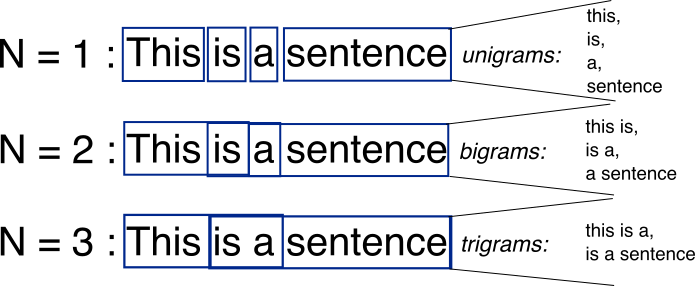

Exemplary split of a phrase into uni-, bi- and trigrams

### 8.7.1 Building Term Document Matrix (TDM/DTM)

Now we will use `TermDocumentMatrix()` to create a `document-term matrix` or `term-document matrix` which is a mathematical matrix that describes the frequency of terms/words/strings that occur in a collection of documents. In a document-term matrix, rows correspond to documents in the collection and columns correspond to terms. There are various schemes for determining the value that each entry in the matrix should take. Read more on n-gram on [wiki](https://en.wikipedia.org/wiki/Document-term_matrix).

Now we will find out most frequently occurred words (uni-gram, bi-gram and tri-gram) and visualize.

### 8.7.2 Unigram: Most Frequently Occured Words

```r
# Unigram
uni_token <- function(x) {NGramTokenizer(x, Weka_control(min = 1, max = 1))}
uni_tdm <- TermDocumentMatrix(myCorpus, control = list(tokenize = uni_token))
#uni_tdm <- removeSparseTerms(uni_tdm, 0.95)
uni_corpus <- findFreqTerms(uni_tdm,lowfreq = 50)
uni_corpus_freq <- rowSums(as.matrix(uni_tdm[uni_corpus,]))
uni_corpus_freq <- data.frame(word=names(uni_corpus_freq), frequency=uni_corpus_freq)
df1<- uni_corpus_freq[order(-uni_corpus_freq$frequency),][1:20,]
df1<-df1[complete.cases(df1),]
```

Top 20 frequently occurred words are..

```r
df1[1:20,]
```

```
##        word frequency
## just   just      2974
## get     get      2968
## will   will      2961
## one     one      2959
## like   like      2947
## can     can      2940
## said   said      2516
## time   time      2492
## year   year      2215
## day     day      2196
## love   love      2025
## make   make      1961
## good   good      1906
## know   know      1800
## now     now      1785
## new     new      1775
## work   work      1682
## thank thank      1567
## see     see      1543
## want   want      1524
```

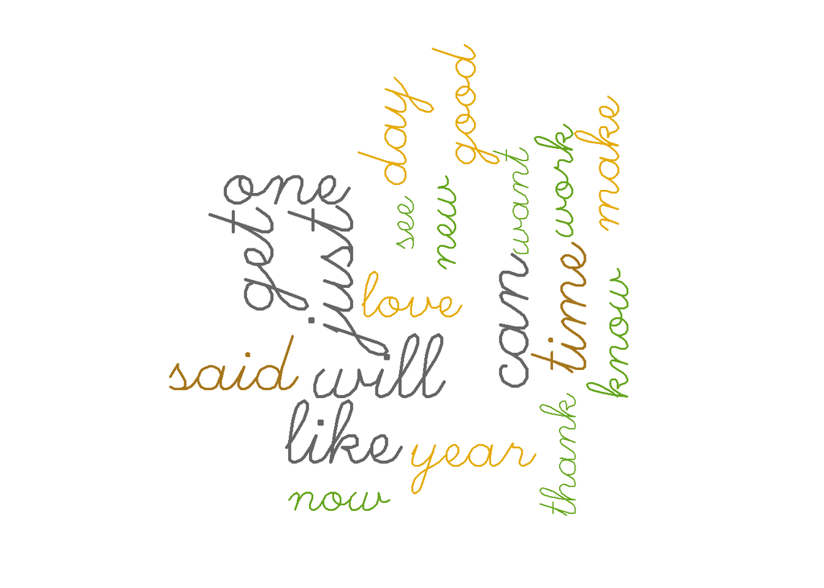

```r
#We have built a word cloud using top 50 frequent words from sample data.
wordcloud(words = df1$word, freq = df1$frequency, min.freq = 50,
        max.words=50, random.order=TRUE, rot.per=0.75,
        colors=brewer.pal(8, "Dark2"), c(5,.5), vfont=c("script","plain"))
```

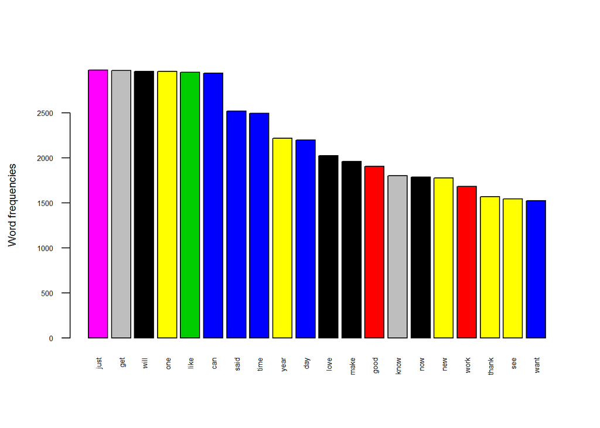

```r
barplot(df1[1:20,]$freq, las = 2, names.arg = df1[1:20,]$word,
        col =df1[1:20,]$freq, main ="",
        ylab = "Word frequencies", cex.axis=.5, cex = .5, cex.lab=0.75, cex.main=.75)
```

### 8.7.3 Bigram: Most Frequently occured “sequence of two adjacent elements”

```r
#Bigram
bi_token <- function(x) {NGramTokenizer(x, Weka_control(min = 2, max = 2))}
bi_tdm <- TermDocumentMatrix(myCorpus, control = list(tokenize = bi_token))
bi_corpus <- findFreqTerms(bi_tdm,lowfreq = 10)
bi_corpus_freq <- rowSums(as.matrix(bi_tdm[bi_corpus,]))
bi_corpus_freq <- data.frame(word=names(bi_corpus_freq), frequency=bi_corpus_freq)
df2 <- bi_corpus_freq[order(-bi_corpus_freq$frequency),][1:20,]
```

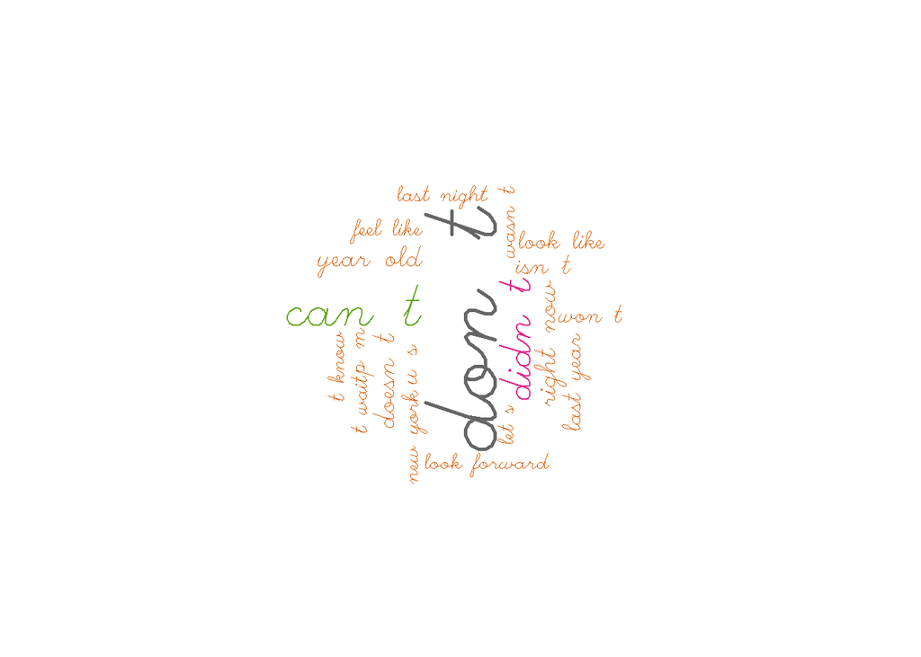

```r
wordcloud(words = df2$word, freq = df2$frequency, min.freq = 1,
        max.words=100, random.order=FALSE, rot.per=0.75,
        colors=brewer.pal(8, "Dark2"), c(5,.5), vfont=c("script","plain"))
```

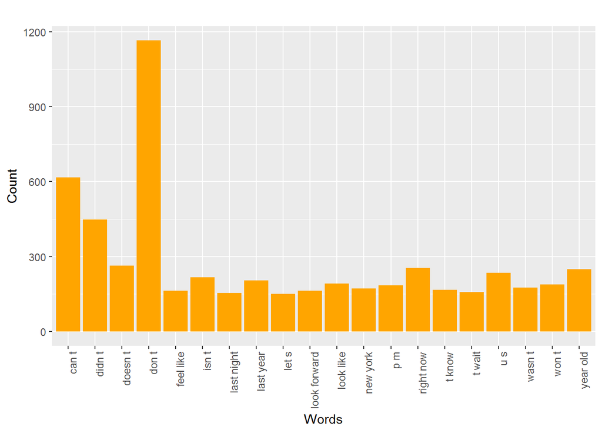

```r
ggplot(df2, aes(x = df2$word, y = frequency)) +
    geom_bar(stat = "identity", fill = "orange") +
    labs(title = " ") +
    xlab("Words") +
    ylab("Count")+
    theme(axis.text.x = element_text(angle = 90, hjust = 1))
```

### 8.7.4 Trigram: Most Frequently occured “a group of three consecutive written units such as letters, syllables, or words”

```r
#Trigram
tri_token <- function(x) {NGramTokenizer(x, Weka_control(min = 3, max = 3))}
tri_tdm <- TermDocumentMatrix(myCorpus, control = list(tokenize = tri_token))
tri_corpus <- findFreqTerms(tri_tdm,lowfreq = 5)
tri_corpus_freq <- rowSums(as.matrix(tri_tdm[tri_corpus,]))
tri_corpus_freq <- data.frame(word=names(tri_corpus_freq), frequency=tri_corpus_freq)
df3<-tri_corpus_freq[order(-tri_corpus_freq$frequency),][1:20,]
```

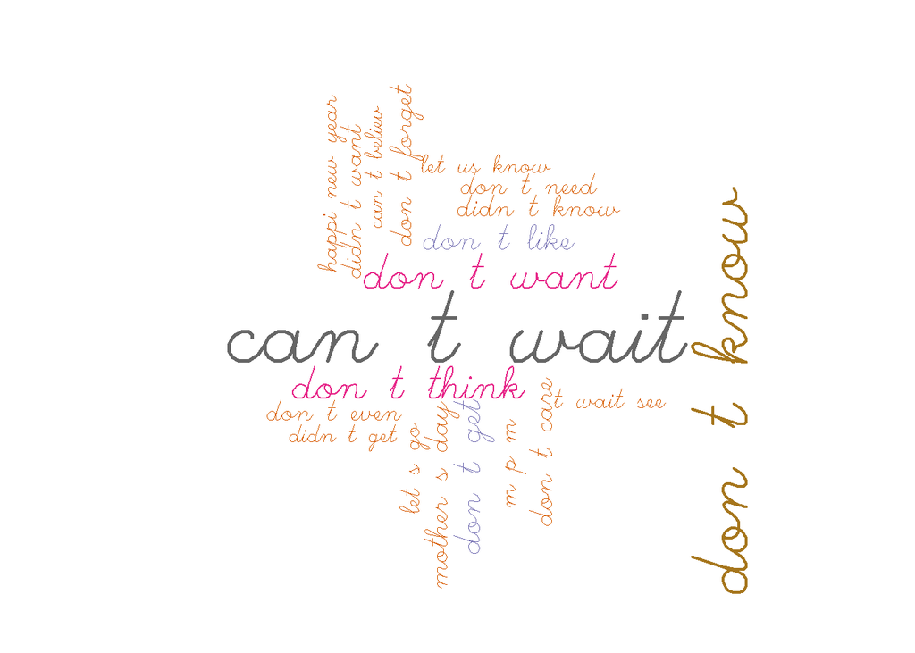

```r
wordcloud(words = df3$word, freq = df3$frequency, min.freq = 1,
        max.words=100, random.order=FALSE, rot.per=0.60,
        colors=brewer.pal(8, "Dark2"), c(5,.5), vfont=c("script","plain"))
```

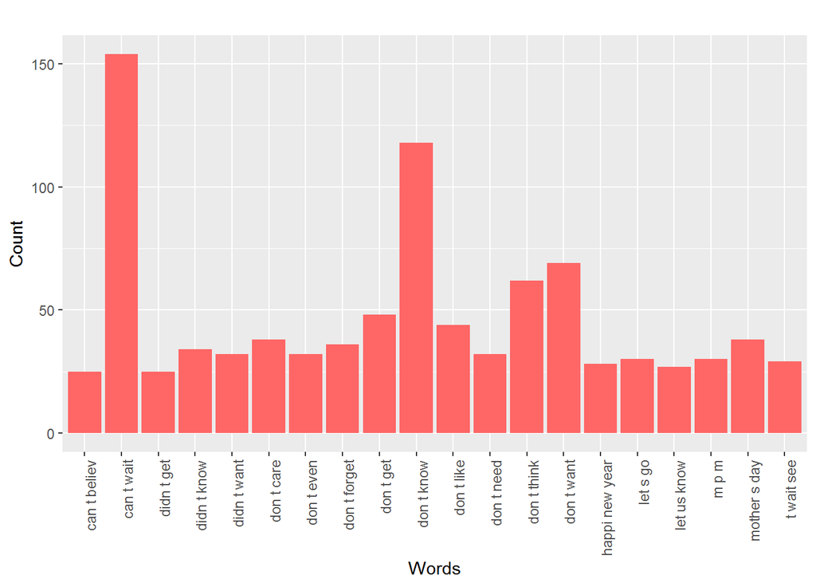

```r
ggplot(df3, aes(x = df3$word, y = frequency)) +
    geom_bar(stat = "identity", fill = "#FF6666") +
    labs(title = " ") +
    xlab("Words") +
    ylab("Count")+
    theme(axis.text.x = element_text(angle = 90, hjust = 1))
```

## 8.8 Next Steps

- Improve the text analysis
- Develop predictive models to predict text
- Improve model performance
- Implement the predictive models on [**R-Shiny**](https://shiny.rstudio.com/)

## 8.9 References

- [David Guthrie; et al. (2006). “A Closer Look at Skip-gram Modelling”]http://homepages.inf.ed.ac.uk/ballison/pdf/lrec_skipgrams.pdf
- Wiki [n-gram](https://en.wikipedia.org/wiki/N-gram)
- [Text Mining, Analytics & More](http://text-analytics101.rxnlp.com/2014/11/what-are-n-grams.html)
- [Daniel Jurafsky & James H. Martin. Draft of September 1, 2014. “Speech and Language Processing”](https://lagunita.stanford.edu/c4x/Engineering/CS-224N/asset/slp4.pdf)
- [“Data Science Specialization” by Johns Hopkins University](https://www.coursera.org/specializations/jhu-data-science)
- Basic Text Analysis - [N-Gram Models](http://stp.lingfil.uu.se/~nivre/stp/N-gram.pdf)
- [Relationships between words: n-grams and correlations](https://www.tidytextmining.com/ngrams.html)
- [Text Mining with R - A Tidy Approach by Julia Silge and David Robinson](https://www.tidytextmining.com/)
- [Statistical methods for linguistic research: Foundational Ideas](http://www.ling.uni-potsdam.de/~vasishth/pdfs/StatMethLingPart1.pdf)
- [A Programmer’s Guide to Data Mining](http://guidetodatamining.com/)
- [Comparing n-gram models](http://recognize-speech.com/language-model/n-gram-model/comparison)

# 9 R Markdown

## 9.1 Output Formating options used

```
output:
  html_document:
    toc: true
    toc_depth: 5
    toc_float: true
    number_sections: true
    code_folding: hide
```

To know more on formatting click here http://rmarkdown.rstudio.com/html_document_format.html#table_of_contents.